chapter 11 模型评估与优化

# 使用交叉验证进行模型评估

除了之前的 train_test_split 函数外，还有更自动化的拆分测试工具。就是交叉验证法(Cross Validation)。

K折叠交叉验证法(k-fold cross validation):

- 把数据随机拆分成k份，对k-1份训练，使用1份测试。
- 循环k次，则每份都做过测试集。
- 对外输出5次测试集的打分平均数。

```python
# 导入红酒数据集
from sklearn.datasets import load_wine
# 导入交叉验证工具
from sklearn.model_selection import cross_val_score
# 导入用于分类的支持向量机模型
from sklearn.svm import SVC

# 载入数据
wine = load_wine()
# 设置 SVC 的核函数为 linear
svc = SVC(kernel='linear')
# 使用交叉验证法对SVC进行评分
scores=cross_val_score(svc, wine.data, wine.target, cv=5) #默认分成5份

print(scores, "\nMean score:{:0.3f}".format(scores.mean()) )
```

```
[0.88888889 0.94444444 0.97222222 1.         1.        ]
Mean score:0.961
```

```python
# sklearn对分类模型，默认使用的是 分层k交叉验证法。
print(wine.target) #可见酒分了3类。

# 所谓的分层，就是如果目标是80%男，20%女，则拆分数据后每一份中男女也是这个比例。
```

```
[0 0 0 0 0 0 0 0 0 0 0 0 0 0 0 0 0 0 0 0 0 0 0 0 0 0 0 0 0 0 0 0 0 0 0 0 0
 0 0 0 0 0 0 0 0 0 0 0 0 0 0 0 0 0 0 0 0 0 0 1 1 1 1 1 1 1 1 1 1 1 1 1 1 1
 1 1 1 1 1 1 1 1 1 1 1 1 1 1 1 1 1 1 1 1 1 1 1 1 1 1 1 1 1 1 1 1 1 1 1 1 1
 1 1 1 1 1 1 1 1 1 1 1 1 1 1 1 1 1 1 1 2 2 2 2 2 2 2 2 2 2 2 2 2 2 2 2 2 2
 2 2 2 2 2 2 2 2 2 2 2 2 2 2 2 2 2 2 2 2 2 2 2 2 2 2 2 2 2 2]
```

## 随机拆分法(shuffle-split corss-validation)

```python
# 原理：先从数据中随机抽取一部分作为训练集，再从其余部分随机抽取一部分作为测试集，进行评分后再迭代，
#    直到达到我们希望的迭代次数。

from sklearn.model_selection import ShuffleSplit
# 设置拆分为10份
shuffle_split = ShuffleSplit(train_size=0.7, test_size=0.2, n_splits=10)
# 交叉验证
scores=cross_val_score(svc, wine.data, wine.target, cv=shuffle_split)
print(scores, "\nMean score:{:0.3f}".format(scores.mean()) )
```

```
[0.91666667 0.97222222 0.94444444 0.97222222 0.97222222 0.97222222
 0.91666667 0.91666667 0.97222222 1.        ]
Mean score:0.956
```

## 挨个儿试试法( leave-one-out )

```python
# 原理：每次取一个作为测试集，其他作为训练集。缺点是耗时，特别是对大数据集。

from sklearn.model_selection import LeaveOneOut
loo = LeaveOneOut()
# 交叉验证
scores=cross_val_score(svc, wine.data, wine.target, cv=loo)
print(scores, "\nMean score:{:0.3f}".format(scores.mean()) )
```

```
[1. 1. 1. 1. 1. 1. 1. 1. 1. 1. 1. 1. 1. 1. 1. 1. 1. 1. 1. 1. 1. 1. 1. 1.
 1. 0. 1. 1. 1. 1. 1. 1. 1. 1. 1. 1. 1. 1. 1. 1. 1. 1. 1. 1. 1. 1. 1. 1.
 1. 1. 1. 1. 1. 1. 1. 1. 1. 1. 1. 1. 1. 0. 1. 1. 1. 1. 1. 1. 1. 1. 0. 1.
 1. 0. 1. 1. 1. 1. 1. 1. 1. 1. 1. 0. 1. 1. 1. 1. 1. 1. 1. 1. 1. 1. 1. 0.
 1. 1. 1. 1. 1. 1. 1. 1. 1. 1. 1. 1. 1. 1. 1. 1. 1. 1. 1. 1. 1. 1. 1. 1.
 1. 1. 1. 1. 1. 1. 1. 1. 1. 1. 0. 1. 1. 1. 0. 1. 1. 1. 1. 1. 1. 1. 1. 1.
 1. 1. 1. 1. 1. 1. 1. 1. 1. 1. 1. 1. 1. 1. 1. 1. 1. 1. 1. 1. 1. 1. 1. 1.
 1. 1. 1. 1. 1. 1. 1. 1. 1. 1.]
Mean score:0.955
```

# 使用网络搜索优化模型参数

除了逐个尝试看打分外，还可以使用网络搜索法一次性找到更优的参数设置。

## 简单网络搜索

```python
# 目的: 尝试2个参数的组合 max_iter=100,1000,5000,10000, alpha=10,1,0.1,0.01;

from sklearn.datasets import load_wine
wine = load_wine()

# 导入套索回归模型
from sklearn.linear_model import Lasso
# 导入数据集拆分工具
from sklearn.model_selection import train_test_split
# 将数据集拆分为训练集与测试集
X_train, X_test, y_train, y_test = train_test_split(wine.data, wine.target, random_state=38)

# 设置初试分数0
best_score=0
# 设置 alpha 参数4个遍历
for alpha in [0.01, 0.1, 1, 10]:
    #设置最大迭代次数, 4个遍历
    for max_iter in [100, 1000, 5000, 10000]:
        lasso=Lasso(alpha=alpha, max_iter=max_iter)
        lasso.fit(X_train, y_train)
        score=lasso.score(X_test, y_test)
        # print(alpha, max_iter, score)
        # 最高分数
        if score > best_score:
            best_score=score
            best_parameters={"alpha":alpha, "max_iter":max_iter}
# 输出
print("best_score:{:0.3f}".format(best_score))
print("best_parameters:{}".format(best_parameters))
```

```
best_score:0.889
best_parameters:{'alpha': 0.01, 'max_iter': 100}
```

```python
# 上述做法是有缺陷的，因为16次评分使用的是同一个训练集和测试集。不能反映出新数据及的情况。

# 比如换一个拆分方法，打分也会变 random_state=0
X_train, X_test, y_train, y_test = train_test_split(wine.data, wine.target, random_state=0)

best_score=0
for alpha in [0.01, 0.1, 1, 10]:
    for max_iter in [100, 1000, 5000, 10000]:
        lasso=Lasso(alpha=alpha, max_iter=max_iter)
        lasso.fit(X_train, y_train)
        score=lasso.score(X_test, y_test)
        if score > best_score:
            best_score=score
            best_parameters={"alpha":alpha, "max_iter":max_iter}
# 输出
print("best_score:{:0.3f}".format(best_score))
print("best_parameters:{}".format(best_parameters))

# 改变拆分方法后，最佳参数变为 alpha=0.1, 最佳打分也下降了
```

```
best_score:0.830
best_parameters:{'alpha': 0.1, 'max_iter': 100}
```

## 与交叉验证结合的网络搜索

```python
import numpy as np
from sklearn.model_selection import cross_val_score

best_score=0
for alpha in [0.01, 0.1, 1, 10]:
    for max_iter in [100, 1000, 5000, 10000]:
        lasso=Lasso(alpha=alpha, max_iter=max_iter)
        scores = cross_val_score(lasso, X_train, y_train, cv=6)
        score=np.mean(scores)
        if score > best_score:
            best_score=score
            best_parameters={"alpha":alpha, "max_iter":max_iter}
# 输出
print("best_score:{:0.3f}".format(best_score))
print("best_parameters:{}".format(best_parameters))
```

```
best_score:0.865
best_parameters:{'alpha': 0.01, 'max_iter': 100}
```

```python
# 再试试验证集上，使用最优参数
lasso=Lasso(alpha=0.01, max_iter=100).fit(X_train, y_train)
print("test score:{:0.3f}".format(lasso.score(X_test, y_test)))

# 这个打分有点低。因为lasso会舍弃特征，而我们的特征本来就不多，说明舍弃的列不那么冗余。
```

```
test score:0.819
```

```python
# 使用内置的 GridSearchCV 简化上述循环

#导入网络搜索工具
from sklearn.model_selection import GridSearchCV
params = {'alpha':[0.01, 0.1, 1, 10], 'max_iter':[100,1000,5000,10000]}
# 定义模型和参数
grid_search = GridSearchCV(lasso, params, cv=6)
grid_search.fit(X_train, y_train)

# 打分
print("test score:{:0.3f}".format(grid_search.score(X_test, y_test)))
print("best params:", grid_search.best_params_)

# 最佳条件和上面的for循环一样。
# 注意: grid_search.best_score_ 中存储的是交叉验证的最高分，而不是在测试集上的得分。
print("\nbest_score_:{:0.3f}".format(grid_search.best_score_))
```

```
test score:0.819
best params: {'alpha': 0.01, 'max_iter': 100}

best_score_:0.865
```

# 分类模型的可信度评估

## 分类模型中的预测准确率

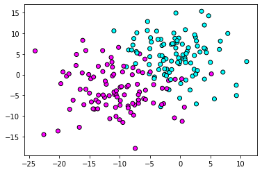

```python
import numpy as np
import matplotlib.pyplot as plt

from sklearn.datasets import make_blobs
import matplotlib.pyplot as plt

X, y= make_blobs(n_samples=200, random_state=1, centers=2, cluster_std=5)
plt.scatter(X[:, 0], X[:, 1], c=y, cmap=plt.cm.cool, edgecolor='k')
plt.show()
# 假设深红色 1，浅色0
```

```python
# 导入高斯贝叶斯模型
from sklearn.naive_bayes import GaussianNB
# 数据集拆分
from sklearn.model_selection import train_test_split
X_train, X_test, y_train, y_test = train_test_split(X, y, random_state=68)
# 训练高斯贝叶斯模型
gnb=GaussianNB()
gnb.fit(X_train, y_train)

predict_prob = gnb.predict_proba(X_test)
print(predict_prob.shape) #(50, 2)
predict_prob[:3]
# 第一行是归为2个分类的概率 98.8% vs 1.2%
```

```
(50, 2)
```

```
array([[0.98849996, 0.01150004],
       [0.0495985 , 0.9504015 ],
       [0.01648034, 0.98351966]])
```

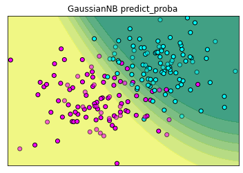

```python
# 可视化分类过程中的表现

x_min, x_max= X[:,0].min()-0.5, X[:,0].max()+0.5
y_min, y_max= X[:,1].min()-0.5, X[:,1].max()+0.5
xx, yy = np.meshgrid(np.arange(x_min, x_max, 0.02),
                    np.arange(y_min, y_max, 0.02))
Z=gnb.predict_proba(np.c_[xx.ravel(), yy.ravel()])[:,1]
Z=Z.reshape(xx.shape)

#绘制等高线
plt.contourf(xx, yy, Z, cmap=plt.cm.summer, alpha=0.8)
plt.scatter(X_train[:,0], X_train[:,1], c=y_train, cmap=plt.cm.cool, edgecolor='k')
plt.scatter(X_test[:,0], X_test[:,1], c=y_test, cmap=plt.cm.cool, edgecolor='k', alpha=0.6)
# 设置坐标轴范围
plt.xlim(xx.min(), xx.max())
plt.ylim(yy.min(), yy.max())
# 设置横纵轴的单位
plt.xticks(())
plt.yticks(())

plt.title("GaussianNB predict_proba")
plt.show()
# 背景颜色代表概率值。半透明的点是测试集。

# 并不是每个分类算法都有 predict_proba 属性。
#  不过我们还可以使用另一种方法检查分类的可信度，就是决定系数 decision_function.
```

## 分类模型中的决定系数

决定系数只返回一个值，正数代表属于分类1，负数代表属于分类2.

由于高斯朴素贝叶斯没有 decision_function，我们换成 支持向量机SVC 算法来进行建模。

```python
from sklearn.svm import SVC
svc=SVC().fit(X_train, y_train)
dec_func= svc.decision_function(X_test)
# 打印决定系数的前5个
print(dec_func[:5])
# 负数一类，正数一类。
```

```
[-1.36071347  1.53694862  1.78825594 -0.96133081  1.81826853]
```

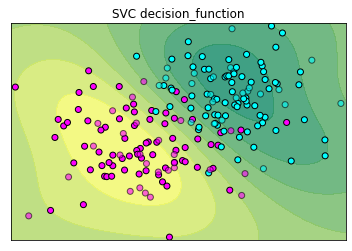

```python
# 可视化工作原理
Z=svc.decision_function(np.c_[xx.ravel(), yy.ravel()])
Z=Z.reshape(xx.shape)
# 绘制等高线
plt.contourf(xx, yy, Z, cmap=plt.cm.summer, alpha=0.8)

# 绘制散点图
plt.scatter(X_train[:,0], X_train[:,1], c=y_train, cmap=plt.cm.cool, edgecolor='k')
plt.scatter(X_test[:,0], X_test[:,1], c=y_test, cmap=plt.cm.cool, edgecolor='k', alpha=0.6)

plt.xlim(xx.min(), xx.max())
plt.ylim(yy.min(), yy.max())

plt.title("SVC decision_function")
# 设置横纵轴的单位
plt.xticks(())
plt.yticks(())
plt.show()

# 和上图类似，有一个斜对角线分界线。
#  但是深背景色的核心位置不同。处于区域中心的是高度可信的，而边缘区域和交界区域的，则是“模棱两可”区域。
```

本例汇总使用的是二元分类任务，但是 predict_proba 和 decision_function 同样适用于多元分类任务。

- 感兴趣的读者可以调整 make_blobs 的 centers 参数进行试验。

## 其它模型评价指标

之前一直使用的 .score(),

- 对于分类模型，给出的是模型分类的准确率(accuracy)；
- 对于回归模型，给出的是回归分析中的R^2分数，翻译为 可决系数，或 拟合优度。（决定系数）
  - R^2 的计算方法是用 “回归平方和”(explain sum of squares, ESS) 除以“总变差”(total sum of squares, TSS)

R^2 = 1 - 求和(y-y_hat)^2/求和(y-y_bar)^2

其它指标

- 精度 Precision
- 召回率 Recall
- f1分数 f1-score
- ROC(Receiver Operating Characteristic Curve)
- AUC(Area Under Curve)

这些指标经常和 网格搜索算法 配合使用，选择合适的模型和参数。

- 如果使用 GridSearchCV 类，需要改变评分方法，只需要修改 scoring 参数即可。
- 随机森林，修改评分为 roc_auc:
  - grid=GridSearchCV(RandomForestClassifier(), param_grid=param_grid, scoring='roc_auc')